# Isochrones 101: “How far is everything?”

[figure not shown]

Going places!

## Objective:

Now that we’ve discussed what Isochrones are and how we could use them, let’s follow along on a coding example and create our own!

## Requirements:

1. [R and R Studio](https://posit.co/download/rstudio-desktop/)
2. [Java 11 SDE](https://www.oracle.com/java/technologies/downloads/#java11)
3. R Packages (We have an install line for all packages!)
   - R5R - Rapid Realistic Routing for our isochrone generator
   - sf - Spatial package.
   - data.table - Data wrangling
   - interp
   - tidyverse - Cleaning dataframes
   - tidytransit - Helps us read GTFS feeds.
   - mapview - Spatial visualization.

## Data:

1. [NYC OpenStreetMap Data which we’ve filtered (you can use your own .pbf files for your own analysis!)](https://github.com/vpeter-fitp/isochrones_tcnyc2023/blob/main/data/nyc.pbf)
2. [NYC Subway GTFS Feed from Transit.Land (for this demonstration, we’ve provided the file here.)](https://github.com/vpeter-fitp/isochrones_tcnyc2023/blob/main/data/nyctsubway.zip)

## You can download the data and run these snippets by yourself!

Now let’s jump into the demonstration.

## Installing Packages and Loading

Let’s install the required packages:

```r
install.packages(c('r5r','sf','data.table','interp','tidyverse','tidytransit','mapview'))
```

Now we load them:

```r
options(java.parameters = "-Xmx4G")

library(r5r)
library(sf)
library(data.table)
library(interp)
library(tidyverse)
library(tidytransit)
```

## Pointing to our data locations

You’d want to keep all the required files in the same directory. We now point to the current working directory.

```r
data_path <- getwd()
```

## Initiating R5R, the Routing Engine

The routing engine or R5R needs something to route. So let’s point and create a network. In this case, you can use the demo ‘.pbf’ file which gives the routing engine the required information such as transit options, roads, POIs etc. The routing engine uses this to create a ‘Network’ file.

Here’s what it looks like:

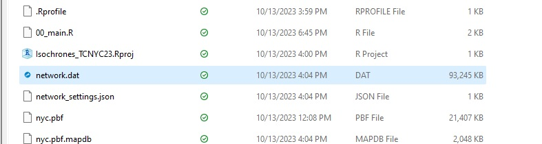

‘Our precious network file’

And here’s the setup code which does the same using the specified path. It will use the .pbf file found there and create the network file.

```r
r5r_core <- setup_r5(data_path)
```

```
## No raster .tif files found. Using elevation = 'NONE'.
```

```
## Using cached R5 version from C:/Users/VickramPeter/AppData/Local/R/cache/R/renv/cache/v5/R-4.2/x86_64-w64-mingw32/r5r/1.1.0/310d39ba2958f91a655580ac1433999e/r5r/jar/r5-v6.9-all.jar
```

```
##
## Using cached network.dat from C:/OD/OneDrive - Foursquare ITP/Documents/Isochrones_TCNYC23/network.dat
```

## Importing GTFS data

Given our NYC Subway data as a .zip file, we use tidytransit to process the packed file and make it easier for us to work with it.

```r
gtfs_base <- tidytransit::read_gtfs(file.path(data_path,'nyctsubway.zip'))
```

Before we continue, let’s look at and think about the applications of experimenting with this GTFS data.

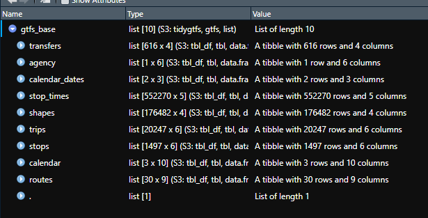

view(gtfs_base)

While there are useful fields of information, we’re focused on deriving the location of subway station stops. Having an idea of where the Subway runs helps us understand the travelling time associated with our isochrones.

Let’s extract the geospatial indicators, or, the latitude and logitude of our stops.

```r
stops<-gtfs_base$stops %>%
  select(stop_name,parent_station,stop_lat,stop_lon)
```

A little bit of cleaning:

```r
stops_clean <- stops %>%
  group_by(parent_station) %>%
  filter(row_number()==1)
```

Now that we’ve got a dataframe with this geo-spatial reference, we have to convert it to the format R5R requires it to be in.

Here are the columns required:

- id : A unique identifier for each point
- lat : latitude
- lon: longitude

Let’s format our data:

```r
points <- stops_clean %>%
  rename(id=parent_station,lat = stop_lat, lon = stop_lon)
```

## Where are we?

Let’s find out where we can start our isochrone search from. The centre.

[figure not shown]

view(points)

Based, on this, let’s start at Jay St. Metrotech.

```r
central_point <- points[211,]
```

## The Legend

The first and second parameters are the lower and upper timing limits respectively for visualization. The third value is the change step.

```r
time_intervals <- seq(0, 60, 6)
```

### Specifying our Parameters for the Search

```r
mode <- c("WALK", "TRANSIT")
max_walk_time <- 15
max_trip_duration <- 60
time_window <- 60
departure_datetime <- as.POSIXct("10-10-2023 09:00:00", format = "%d-%m-%Y %H:%M:%S")
```

### Let’s Run the Engine!

```r
isochrome_result <- r5r::isochrone(r5r_core,
                       origins = central_point,
                       mode = mode,
                       cutoffs = time_intervals,
                       sample_size = 1,
                       departure_datetime = departure_datetime,
                       max_walk_time = max_walk_time,
                       max_trip_duration = max_trip_duration,
                       time_window = time_window,
                       progress = FALSE)
```

### Creating the NYC Subway Stops for Visualization

Remember how we created those points? That was the format required for the Isochrones function.

Let’s create the spatial geometry from that point using R’s premier sf package.

```r
stops_sf= st_as_sf(points, coords = c("lon","lat"), crs = 4326L, remove = FALSE)
```

### Let the Isochrome be viewed!

The generated isochrome_result needs to be visualizaed. Here, we use mapview to do so. ‘zcol’ is the parameter required to display the isochrones correctly (atop each other). ‘alpha.regions’ is a visualisation parameter.

Additionally, we also visualize the stops for reference.

To finally arrive at:

```r
mapview::mapview(isochrome_result, zcol = "isochrone", alpha.regions = 0.25) + mapview::mapview(stops_sf,lwd=0.5)
```

[output not shown]

[interactive chart not shown]

# Congratulations!

You’ve just developed your first Isochrone!

We’d recommend you try this out for areas that are special or cool to you! Or simply see how the transit systems affect it.

### Thanks for joining us today!

We’d be more than happy to run through this demo with you! OR Reach out if you’d ever want to discuss Transit Data, Commuter flows, and Cool GTFS & Spatial tools.

Our inbox is always open at:

- [Wylie Timmerman, Senior Transportation Planner & Data Science Team Technical Lead](https://www.foursquareitp.com/staff/wylie-timmerman/)
- [Vickram Peter, Transportation Planner & Data Scientist](https://www.foursquareitp.com/staff/vickram-peter/)